# Solutions Exercise 5 - Periodic review policy

Inventory Management

Thomas Kirschstein

# Periodic review with fixed lead time (I)

1. What is the lead time and the critical ratio? Determine the cost-optimal order-up level $S$.

Lead time is 0 and the risk period is one week as the shop is closed at the weekend. The critical ratio is $CR = \frac{c^{bo}}{c^{sh} +c^{bo}} = \frac{3}{3 + 0.5}=0.8571$. Thus, the cost-optimal $S$ is $S^* = \mu + \sigma \cdot \Phi^{-1}(0.8571)=100+10 \cdot 1.068 \approx$ 111 pieces.

2. What are the optimal total cost as well as $\alpha$ and $\beta$ service level for the solution from 1.?

The optimal expected cost (at the end of the order cycle) is $E(C(S^*)) = (c^{sh} + c^{bo}) \cdot \sigma \cdot \varphi(\Phi^{-1}(CR)) = 3.5 \cdot 10 \cdot \varphi(1.068) \approx$ 7.9 Euro per week.

The $\alpha$ service level is equal to the critical ratio (i.e., 85.71%). As $RP=T=1$, this holds for each perspective (basic period, risk period and order interval). The $\beta$ service level requires to calculate the expected loss $L(Y^{RP},S)$ which is 0.7307. Thus, it follows $\beta=1-\frac{L(Y^{RP},S)}{\mu}=$ 99.3%.

3. Assume now that the supplier delivers two week later. Recalculate the cost-optimal $S$.

Now the risk period is 3 weeks. Thus, $\mu_{RP} = 3\cdot 100= 300$ and $\sigma_{RP}=\sqrt{3} \cdot 10\approx 17.32$ such that $S^* = \mu_{RP} + \sigma_{RP} \cdot \Phi^{-1}(0.8571)=300+17.32 \cdot 1.068 \approx$ 318 pieces.

4. Based on the assumptions of 3., which order-up level $S$ is required to assure a $\beta$ service level of 97%.

We take the order-interval perspective. Therefore, it has to hold $(1-\beta) \cdot \mu_{T} = L(Y_{RP},S)$. With normally distributed demand results $S = \mu_{RP} + \sigma_{RP} \cdot L^{-1}\left(Z,\frac{(1-\beta) \cdot \mu_{T} }{ \sigma_{RP} } \right)$. The argument of the inverse standard loss function is 0.1732051 such that $L^{-1}\left(Z,0.1732 \right)=$ 0.5826 and, therefore, $S^{\beta } = 300 + 17.32\cdot 0.5826 \approx 310$ pieces.

# Periodic review with fixed lead time (II)

1. Calculate $S$ such that a $\beta$ service level of 99% is reached.

First, we need to assess the fluctuation of demand forecasts. There are two sources of variation: 1) the demand uncertainty and 2) the forecasting bias. To account for both, we estimate the root mean squared error (RMSE) based on the squared forecasting errors:

| demand | forecast | sq.forecast.error |
| --- | --- | --- |
| 232 | 303 | 5041 |
| 370 | 268 | 10404 |
| 406 | 319 | 7569 |
| 206 | 363 | 24649 |
| 345 | 284 | 3721 |
| 349 | 315 | 1156 |
| 294 | 332 | 1444 |
| 294 | 313 | 361 |
| 293 | 303 | 100 |
| 277 | 298 | 441 |
| 296 | 288 | 64 |
| 273 | 292 | 361 |
| 285 | 282 | 9 |
| 320 | 283 | 1369 |
| 368 | 302 | 4356 |
| 245 | 335 | 8100 |
| 321 | 290 | 961 |
| 321 | 306 | 225 |
| 298 | 313 | 225 |
| 316 | 306 | 100 |
| 276 | 311 | 1225 |
| 301 | 293 | 64 |
| 289 | 297 | 64 |
| 299 | 293 | 36 |

The RMSE is then 54.8. In the following we assume normally distributed demand and take the order-interval perspective. The risk period is 3+1=4 months, the expected/forecasted demand $\mu_T$ is 296 with $\sigma_T=$ 54.8. Thus, with normally distributed demand results we have $S = 4 \cdot 296 + \sqrt{4} \cdot 54.8 \cdot L^{-1}\left(Z,\frac{(1-0.99) \cdot 296}{ \sqrt{4} \cdot 54.8 } \right)$. The argument of the inverse standard loss function is 0.0270073 such that $L^{-1}\left(Z,0.027 \right)=$ 1.5345 and, therefore, $S^{\beta } = 1184 + 109.6 \cdot 1.5345 \approx 1352$ tons.

2. Do you think the outlined procedure for determining $S$ is reasonable? If you identify shortcomings, elaborate on them.
- the time series seems to show a seasonal pattern $\Rightarrow$ another forecasting procedure would be better $\Rightarrow$ 3rd order ES or other method
- if pattern exists, the forecasts should comprise the whole year, not only the next month $\Rightarrow$ individual $S$ levels for each month
- if there is no seasonal pattern, there seem to be months with higher and lower volatility $\Rightarrow$ heteroscedastic demand
- in case of heteroscedastic demand assessing the demand distribution in the 4-month risk period should be based on volatility estimates for those periods too.

# Periodic review with stochastic lead time

A microchip manufacturer produces wafer based on monocrystalline silicon. The supply process for silicone is quite erratic as the order lead (given in weeks) varies according to Binomial distribution with $n=6$ and $p=\frac{2}{3}$. The weekly silicone demand (in kg) is assumed to be normally distributed and i.i.d. with $\mu = 250$ and $\sigma = 50$. Assume that every 4 weeks a silicone order is placed with the supplier and a $\alpha$ service level of 97% shall be assured.

1. Determine the order-up level $S$ when using the expected lead time to determine the risk period.

Expected lead time is $n \cdot p = 4$ weeks. Therefore, the risk period is 4+4=8 weeks. The safety stock factor is $\Phi^{-1}(0.97)=1.88$. Thus, it follows $S^{\alpha}= 8 \cdot 250 + \sqrt 8 \cdot 50 \cdot 1.88 \approx 2266$ kg.

2. Determine the order-up level $S$ when approximating the demand in the risk period with $\mu_{RP} = \mu_L \cdot \mu_y + T \cdot \mu_y$ and $\sigma_{RP} = \mu_L \cdot \sigma^2_y + \mu_y^2 \cdot \sigma_L^2 + T \cdot \sigma_y^2$.

For a binomially distributed random variable, $\sigma^2$ is defined as $n\cdot p\cdot (1-p)=1.33$. Thus, it follows $E(Y_{RP}) = 250 \cdot 4 + 250 \cdot 4 = 2000$ $Var(Y_{RP})= 4 \cdot 50^2 + 250^2 \cdot 1.33 + 4 \cdot 50^2 = 103125$. Now, $S$ can be calculated as $S^{\alpha}= 2000 + \sqrt{103125} \cdot 1.88 \approx 2604$ kg.

3. Determine the order-up level $S$ when explicitly taking into account the distribution of demand in the risk period.

To assess the demand distribution in the risk period, we need to calculate the lead time probabilities using $f(k,n,p) = {n \choose k} \cdot p^k \cdot (1-p)^{n-k}$ and cumulative probability.

| lead time (weeks) | probability $f(k,n,p)$ | cum. prob. $F(k,n,p)$ |
| --- | --- | --- |
| 0 | 0.001 | 0.001 |
| 1 | 0.016 | 0.018 |
| 2 | 0.082 | 0.100 |
| 3 | 0.219 | 0.320 |
| 4 | 0.329 | 0.649 |
| 5 | 0.263 | 0.912 |
| 6 | 0.088 | 1.000 |

Now, for each lead time realization we can assess the demand distribution during the lead time.

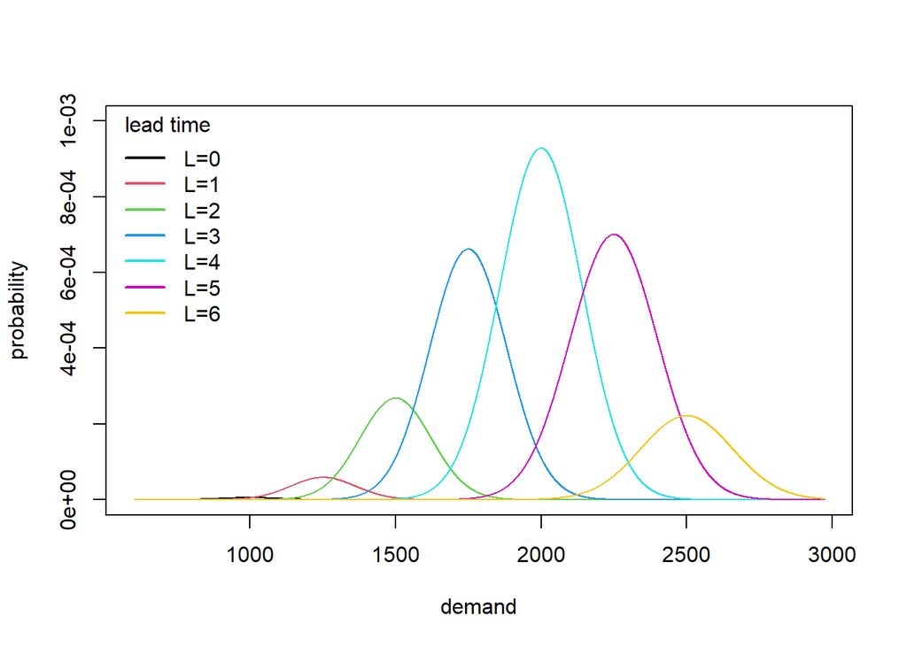

For each lead time realization, the corresponding 97%-quantile of the risk period demand can be computed. As the 97%-quantiles are non-overlapping, it suffices to calculate the 97%-quantile for the highest lead time ($L=6$ weeks). I.e., for $S$ follows $S^{\alpha} = (4+6) \cdot 250 + \sqrt{4+6} \cdot 50 \cdot 1.88 = 2797$.

Simulating the stock performance for 5000 weeks leads to the following $\alpha$ service levels:

| fixed $Y^{RP}$ ($S=2266$) | approx. $Y^{RP}$ ($S=2604$) | real $Y^{RP}$ ($S=2797$) |
| --- | --- | --- |
| 72.55 | 97.41 | 99.76 |

Explanation: The reason that only in 8.8% of all cases, a lead time of $L=6$ occurs. Thus, the probability of observing a demand of $Y^{RP} > 2797$ is not 3% but $0.03 \cdot 0.088 = 0.00264$. Thus, to correct this, one can correct the quantile to $1-\frac{(1-\alpha)}{f(6,6,2/3)}=0.659$. Thus, the 66%-quantile of the demand distribution for $L=6$ is $S^{\alpha} = (6+4)\cdot 250 + \sqrt{10} \cdot 50 \cdot 0.41 \approx 2565$. However, this approach disregards the fact, that also for $L=5$ (and also the other realizations of $L$) a non-zero probability for a demand larger than 2565 exist (to be precise this probability is about $0.005$).

In general, $P(Y^{RP} \leq S) = \sum_{k=0}^n f(k,n,p) \cdot P(Y^k \leq S)$ as $Y^k \sim N( (k+4) \cdot \mu , (k+4) \cdot \sigma^2)$ it follows $P(Y^k \leq S) = \Phi\left(\frac{S-(k+4) \cdot \mu}{ \sqrt{k+4} \cdot \sigma} \right)$. Thus, an $\alpha$ service level of 97% results when $0.97 = \sum_{k=0}^n f(k,n,p) \cdot \Phi\left(\frac{S-(k+4) \cdot \mu}{ \sqrt{k+4} \cdot \sigma} \right)$. However, this equation needs to be solved numerically. Doing so yields $S$:

```
## [1] 2582
```